# Texas Pop Analysis

joshua Brikowski

July 18, 2017

## Texas Population, 2016 (Projections) info

This data was taken from https://www.dshs.texas.gov/chs/popdat/ST2016p.shtm. it had 8 cols labeld FIPS | County | County Name | Total | Anglo | Black | Hispanic | Other.this data represents the enthinic distinction for each county. i have gotten the XLS sheets for 2010-2017.

-For 2011 and 2012 i had issues converting to xls. just chaneg to plain text then it wall copy over.

-2010 contained actual census data thus is not dependent on any predictions.

-Removed the FIPS col since it was just alternateing odd numbers and essentually represented the same thing as the County.

[output not shown]

## helperFunctins

countypop <- gives 2010-2017 data on county plotAll <- plots all of county stats on graph

## Anderson county growth over 10-17

```
##       year           POP            Anglo           Black
##  Min.   :2010   Min.   :58458   Min.   :35565   Min.   :12222
##  1st Qu.:2012   1st Qu.:58905   1st Qu.:35783   1st Qu.:12252
##  Median :2014   Median :59500   Median :35876   Median :12368
##  Mean   :2014   Mean   :59673   Mean   :35843   Mean   :12398
##  3rd Qu.:2015   3rd Qu.:60460   3rd Qu.:35958   3rd Qu.:12525
##  Max.   :2017   Max.   :61127   Max.   :35964   Max.   :12639
##     Hispanic         Other
##  Min.   : 9287   Min.   :1157
##  1st Qu.: 9644   1st Qu.:1204
##  Median :10072   Median :1310
##  Mean   :10121   Mean   :1311
##  3rd Qu.:10572   3rd Qu.:1401
##  Max.   :11046   Max.   :1482
```

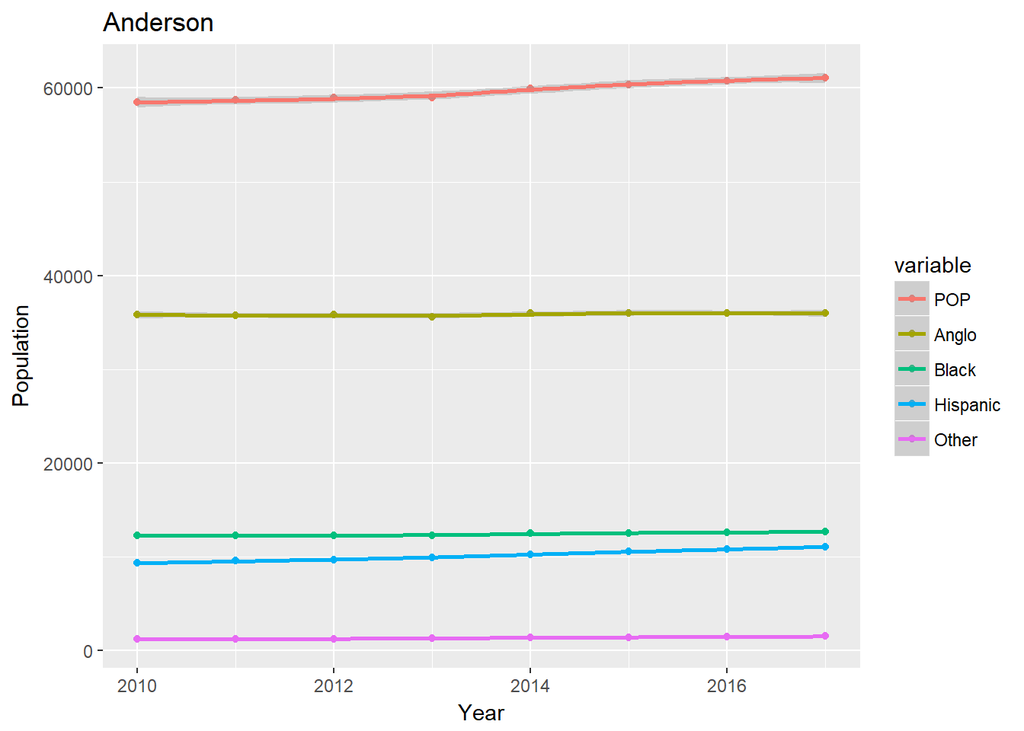

## county with largest change

We can find that harris county has the largest growth of any county. this is probably atributed to it being one of the largest. its biggest demographic growth is hispanic.

```
## [1] 101
```

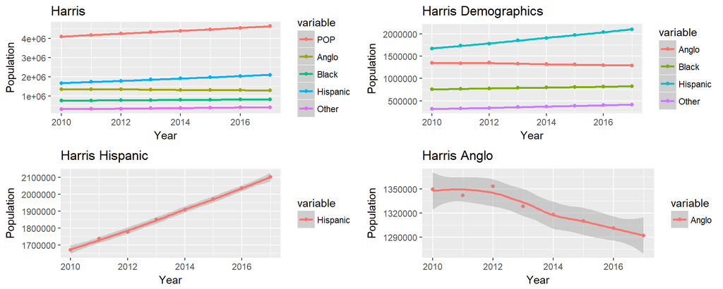

## predict the pop growth for Texas

While the website had the full pop data i decided just to calculate it since i have a computer that can do several million calculations a second and this is about 3000 lines.

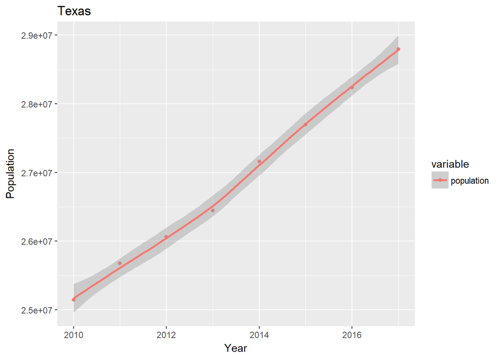